# Statistical Evaluation : Sample Size and Power Calculations for Tests Comparing Proportions in Clinical Research

### 1.2.1 Test for Equality (TSUD_EQUALITY)

**[Research Question]** Suppose that a difference of 20 to 30% in clinical response of cure is considered of clinically meaningful difference between the two compared anti-microbial agents. The study aims to demonstrate that the response rate change between the new anti-microbial agent and active control agent with true cure rate of 65% are different. Given a level of significance of 0.05 and matching ratio between both groups equal to 1, evaluate the sample size range for a test of equality to achieve statistical test powers equal to 70%, 80% and 90%.  
**[Null Hypothesis]** Cure rate of the new anti-microbial agent - Cure rate of the active control agent equals 0  
**[Alternative Hypothesis]** Cure rate of the new anti-microbial agent - Cure rate of the active control agent does not equal 0  
**[Hypothesis Test]** Rejection of the null hypothesis implies difference between the cure rate between both anti-microbial agents  
**[A]** Epsilon : 20 to 30% at 2% intervals  
**[A.1]** Control Response Rate : 65%  
**[A.2]** Treatment Response Rate : 85% to 95% at 2% intervals  
**[B]** Alpha : 0.05  
**[C]** Beta : 0.30, 0.20 and 0.10 corresponding to 70%, 80% and 90% statistical powers  
**[D]** Kappa : 1.0  
**[E]** Delta : 0 testing margin for the Test of Equality hypothesis

**Code Chunk | Output**

```r
##################################
# Defining a range of possible hypothesized values for epsilon
##################################
epsilon=seq(0.20,0.30,0.02)

##################################
# Defining a fixed hypothesized value for p_Reference
##################################
p_Reference=0.65

##################################
# Defining a range of possible hypothesized values for p_ResponseRate
##################################
(p_ResponseRate=p_Reference + epsilon)
```

```
## [1] 0.85 0.87 0.89 0.91 0.93 0.95
```

```r
##################################
# Defining a fixed hypothesized value for the Type I error
##################################
alpha=0.05

##################################
# Defining a range of possible hypothesized values for the Type II error
##################################
beta=c(0.30,0.20,0.10)

##################################
# Defining a fixed hypothesized value for kappa
##################################
kappa=1.0

##################################
# Computing the range of samples sizes based on different levels of Type II errors
##################################
beta_1=beta[1]
(n_Beta30=(p_ResponseRate*(1-p_ResponseRate)/kappa+p_Reference*
             (1-p_Reference))*((qnorm(1-alpha/2)+qnorm(1-beta_1))/
                                      (p_ResponseRate-p_Reference))^2)
```

```
## [1] 54.77709 43.43401 34.86789 28.24908 23.03504 18.85909
```

```r
ceiling(n_Beta30)
```

```
## [1] 55 44 35 29 24 19
```

```r
z_Beta30=(p_ResponseRate-p_Reference)/
  sqrt(p_ResponseRate*(1-p_ResponseRate)/n_Beta30/kappa+p_Reference
       *(1-p_Reference)/n_Beta30)
(Power_Beta30=pnorm(z_Beta30-qnorm(1-alpha/2))+pnorm(-z_Beta30-qnorm(1-alpha/2)))
```

```
## [1] 0.7000044 0.7000044 0.7000044 0.7000044 0.7000044 0.7000044
```

```r
beta_2=beta[2]
(n_Beta20=(p_ResponseRate*(1-p_ResponseRate)/kappa+p_Reference*
             (1-p_Reference))*((qnorm(1-alpha/2)+qnorm(1-beta_2))/
                                      (p_ResponseRate-p_Reference))^2)
```

```
## [1] 69.65881 55.23406 44.34072 35.92372 29.29314 23.98269
```

```r
ceiling(n_Beta20)
```

```
## [1] 70 56 45 36 30 24
```

```r
z_Beta20=(p_ResponseRate-p_Reference)/
  sqrt(p_ResponseRate*(1-p_ResponseRate)/n_Beta20/kappa+p_Reference
       *(1-p_Reference)/n_Beta20)
(Power_Beta20=pnorm(z_Beta20-qnorm(1-alpha/2))+pnorm(-z_Beta20-qnorm(1-alpha/2)))
```

```
## [1] 0.800001 0.800001 0.800001 0.800001 0.800001 0.800001
```

```r
beta_3=beta[3]
(n_Beta10=(p_ResponseRate*(1-p_ResponseRate)/kappa+p_Reference*
             (1-p_Reference))*((qnorm(1-alpha/2)+qnorm(1-beta_3))/
                                      (p_ResponseRate-p_Reference))^2)
```

```
## [1] 93.25338 73.94273 59.35964 48.09167 39.21520 32.10601
```

```r
ceiling(n_Beta10)
```

```
## [1] 94 74 60 49 40 33
```

```r
z_Beta10=(p_ResponseRate-p_Reference)/
  sqrt(p_ResponseRate*(1-p_ResponseRate)/n_Beta10/kappa+p_Reference
       *(1-p_Reference)/n_Beta10)
(Power_Beta10=pnorm(z_Beta10-qnorm(1-alpha/2))+pnorm(-z_Beta10-qnorm(1-alpha/2)))
```

```
## [1] 0.9000001 0.9000001 0.9000001 0.9000001 0.9000001 0.9000001
```

```r
TwoSampleUnpairedDesign.Equality <- as.data.frame(cbind(epsilon,n_Beta30,n_Beta20,n_Beta10))
names(TwoSampleUnpairedDesign.Equality) <- c("Cure.Rate.Change",
                                 "Power=70%",
                                 "Power=80%",
                                 "Power=90%")

##################################
# Restructuring the data
##################################
TwoSampleUnpairedDesign.Equality.Reshaped <- gather(TwoSampleUnpairedDesign.Equality,
                                            "Power=70%","Power=80%","Power=90%",
                                            key="Power",
                                            value="Sample.Size")
TwoSampleUnpairedDesign.Equality.Reshaped$Label <- rep("TSUD_EQUALITY",nrow(TwoSampleUnpairedDesign.Equality.Reshaped))

TwoSampleUnpairedDesign.Equality.Reshaped
```

```
##    Cure.Rate.Change     Power Sample.Size         Label
## 1              0.20 Power=70%    54.77709 TSUD_EQUALITY
## 2              0.22 Power=70%    43.43401 TSUD_EQUALITY
## 3              0.24 Power=70%    34.86789 TSUD_EQUALITY
## 4              0.26 Power=70%    28.24908 TSUD_EQUALITY
## 5              0.28 Power=70%    23.03504 TSUD_EQUALITY
## 6              0.30 Power=70%    18.85909 TSUD_EQUALITY
## 7              0.20 Power=80%    69.65881 TSUD_EQUALITY
## 8              0.22 Power=80%    55.23406 TSUD_EQUALITY
## 9              0.24 Power=80%    44.34072 TSUD_EQUALITY
## 10             0.26 Power=80%    35.92372 TSUD_EQUALITY
## 11             0.28 Power=80%    29.29314 TSUD_EQUALITY
## 12             0.30 Power=80%    23.98269 TSUD_EQUALITY
## 13             0.20 Power=90%    93.25338 TSUD_EQUALITY
## 14             0.22 Power=90%    73.94273 TSUD_EQUALITY
## 15             0.24 Power=90%    59.35964 TSUD_EQUALITY
## 16             0.26 Power=90%    48.09167 TSUD_EQUALITY
## 17             0.28 Power=90%    39.21520 TSUD_EQUALITY
## 18             0.30 Power=90%    32.10601 TSUD_EQUALITY
```

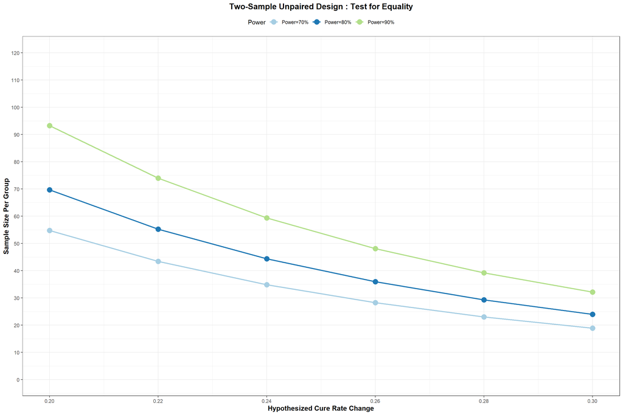

```r
##################################
# Plotting the sample sizes and power curves
##################################
(TwoSampleUnpairedDesign.Equality.PowerAnalysis <- ggplot(TwoSampleUnpairedDesign.Equality.Reshaped,
                                                      aes(x=Cure.Rate.Change,
                                                          y=Sample.Size,
                                                          color=Power)) +
   geom_line(size=1)+
   geom_point(size=4)+
   theme_bw() +
   scale_color_brewer(palette="Paired") +
   scale_x_continuous(name="Hypothesized Cure Rate Change",
                      limits=c(0.2,0.3),
                      breaks=seq(0.2,0.3,by=0.02)) +
  scale_y_continuous(name="Sample Size Per Group",
                     limits=c(0,120),
                     breaks=seq(0,120,by=10)) +
  theme(axis.title.x=element_text(color="black",face="bold",size=12),
        legend.position="top",
        axis.title.y=element_text(color="black",face="bold",size=12),
        plot.title=element_text(color="black",size=14,face="bold",hjust=0.50)) +
  ggtitle("Two-Sample Unpaired Design : Test for Equality"))
```